# Semester Project POLS 3316 Andres Piccone

Author

Andres Piccone

# **Introduction**

Who was the last NBA MVP Award Winner? Nikola Jokic, a Serbian NBA player won last seasons MVP award. In this project I conducted an analysis of the relationship between Nikola Jokic number of games and total number of points through out his NBA season to understand his rise to winning the MVP award. While there have been a lot of great players over the years, one really curious case is that of Nikola Jokic who does not look like your average MVP award winner or even NBA player except for his height. I aim to answer the question whetever the number of games played by Jokic throughout his carreer affect his effectiveness in term of points scored each season.

The importance of of this topic is because as an NBA fan myself, it helps understand more how NBA players nowadays work around the schedules for the NBA season and how the lack or abundance of games affects their performances in terms of points scored per season, especially of an MVP caliber player like Nikola Jokic.

```r
nikolajokic_data<- read.csv("nikolajokic_data.csv")
head(nikolajokic_data)
```

```
   Season Age  Tm  Lg Pos  G GS   MP  FG  FGA   FG. X3P X3PA  X3P. X2P X2PA
1 2015-16  20 DEN NBA   C 80 55 1733 307  600 0.512  28   84 0.333 279  516
2 2016-17  21 DEN NBA   C 73 59 2038 494  854 0.578  45  139 0.324 449  715
3 2017-18  22 DEN NBA   C 75 73 2443 504 1010 0.499 111  280 0.396 393  730
4 2018-19  23 DEN NBA   C 80 80 2504 616 1206 0.511  83  270 0.307 533  936
5 2019-20  24 DEN NBA   C 73 73 2336 565 1071 0.528  80  255 0.314 485  816
6 2020-21  25 DEN NBA   C 72 72 2488 732 1293 0.566  92  237 0.388 640 1056
   X2P.  eFG.  FT FTA   FT. ORB DRB TRB AST STL BLK TOV  PF  PTS Trp.Dbl
1 0.541 0.535 154 190 0.811 181 379 560 189  79  50 104 208  796       0
2 0.628 0.605 188 228 0.825 212 506 718 359  61  55 171 214 1221       6
3 0.538 0.554 266 313 0.850 195 608 803 458  90  61 210 212 1385      10
4 0.569 0.545 289 352 0.821 228 637 865 580 108  55 248 228 1604      12
5 0.594 0.565 246 301 0.817 166 545 711 512  85  44 226 222 1456      13
6 0.606 0.602 342 394 0.868 205 575 780 599  95  48 222 192 1898      16
```

```r
cat("Table 1: Data for  Project")
```

```
Table 1: Data for  Project
```

Table 1: Data for project

## **Summary Statistices of the variables**

Table 2: Summary statistics of Total Points Scored per Season

```r
summary(nikolajokic_data$PTS)
```

```
   Min. 1st Qu.  Median    Mean 3rd Qu.    Max.
    543    1262    1530    2519    1846   12597
```

Table 3: Variance of Total Points Scored per Season

```r
var(nikolajokic_data$PTS)
```

```
[1] 12746161
```

[1] 12746161

Table 4: Standard Deviation of Total Points Scored per Season

```r
sd(nikolajokic_data$PTS)
```

```
[1] 3570.177
```

[1] 3570.177

Table 5: Summary Statistics for Total Games Played per Season

```r
summary(nikolajokic_data$G)
```

```
   Min. 1st Qu.  Median    Mean 3rd Qu.    Max.
  19.00   72.25   73.50  123.00   78.75  615.00
```

Table 6: Variance of Total Games Played per Season

```r
var(nikolajokic_data$G)
```

```
[1] 30200
```

[1] 30200

Table 7: Standard Deviation of Total Games Played per Season

```r
sd(nikolajokic_data$G)
```

```
[1] 173.7815
```

[1] 173.7815

## **Histograms of the variables**

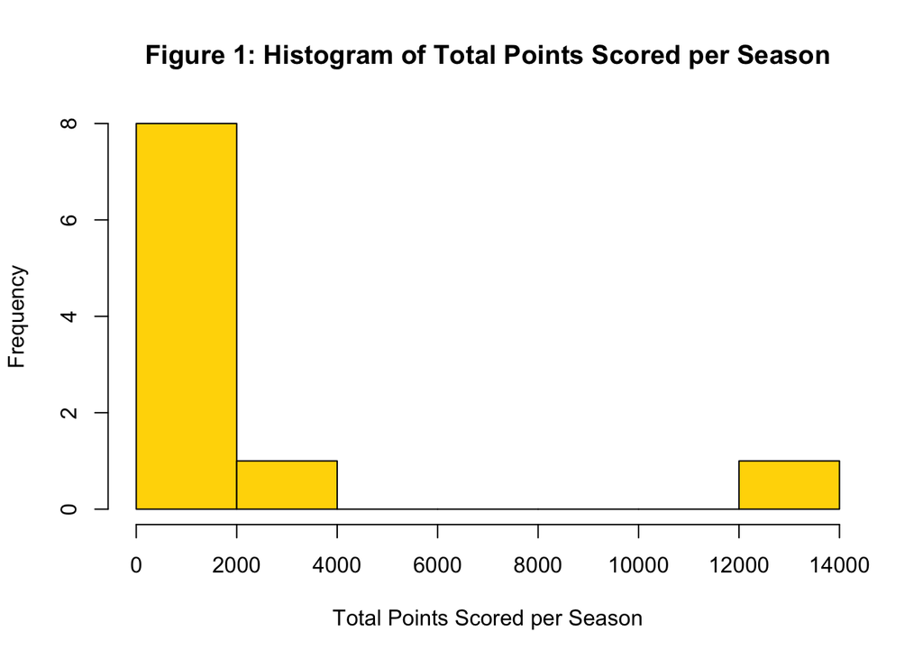

```r
# Histogram of Y variable

hist(nikolajokic_data$PTS, col = "gold", main = "Figure 1: Histogram of Total Points Scored per Season", xlab = "Total Points Scored per Season")
```

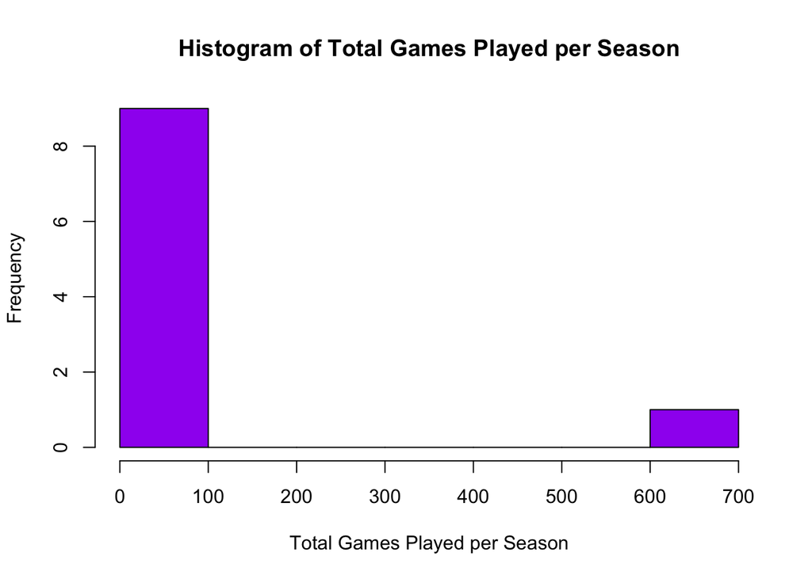

```r
# Histogram of X variable

hist(nikolajokic_data$G, col = "purple", main = "Histogram of Total Games Played per Season", xlab = "Total Games Played per Season")
```

The Correlation Coefficient is 0.994 which suggest that there is a very positive strong linear correlation between the total games played per season and the total points scored per season. The covariance is 616,829.800 which suggest that there is a substantial amount of variation between the two variables. In the end, both values indicate a very strong positive linear relationship and a large amount of variation between both variables.

```r
library(stargazer)
# correlation between variables
varcor <- cor(nikolajokic_data$G, nikolajokic_data$PTS)


#covariance between variables
varcov <- cov(nikolajokic_data$G, nikolajokic_data$PTS)


# correlation and covariance table
corcov <- cbind(varcor, varcov)
stargazer(corcov, type = "text", title = "Table 8: Correlation and Covariance of Variables")
```

```
Table 8: Correlation and Covariance of Variables
==================
varcor   varcov
------------------
0.994  616,829.800
------------------
```

## **Regression Results**

```r
# OLS regression model

#define model object using lm()
model_object2 <- lm(G ~ PTS, data = nikolajokic_data)

# stargazer table of model
library(stargazer)
stargazer(model_object2, type = "text", title = "Table 9: OLS Regression Results", covariate.labels = "Games Played per Season",dep.var.labels = "Points Scored per Season")
```

[output not shown]

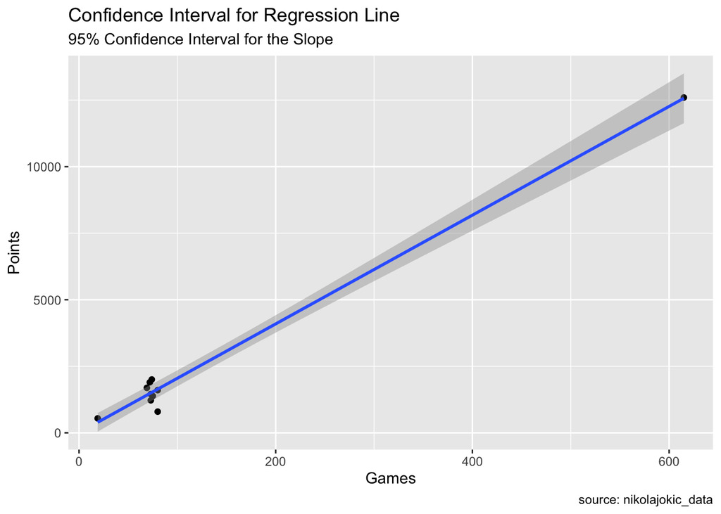

```r
ggplot2::ggplot(data = nikolajokic_data, ggplot2::aes(x = G, y = PTS)) +
  ggplot2::geom_point()+
 ggplot2::geom_smooth(method = "lm", se = TRUE) +
ggplot2::labs(title = "Confidence Interval for Regression Line",
       subtitle = "95% Confidence Interval for the Slope",
       caption = "source: nikolajokic_data") +
      ggplot2::xlab("Games") +
       ggplot2::ylab("Points")
```

## **Conclusion**

The results confirmed the expected relationship from this investigation. The results indicate a increase in points scored the more games are played which states an obvious and logical result that can be tied to more minutes played per game. In the case of continuing with this topic new data about the overall NBA calendar would help in trying to determine more about this topic. Overall, the results indicate that an expected relationship between the two variables shows an increase of points scored the more games were played.

## **Work Cited**

[1] sportradar. (n.d.). *Nikola Jokić stats, height, weight, position, draft status and more*. Basketball. https://www.basketball-reference.com/players/j/jokicni01.html